# HorseRacing

JustinCharbonneau

October 8, 2018

## Introduction

The goal of this analysis is to predict the winner of race horses. Because money would be involved, I dont want to force the prediction on every run, but only predict when the model beleives it will be able to predict the winner from the attributes.

I would be impressed to get good results, as I think that we would need to have much more data, to make a better prediction. A few examples include weight of the horses and riders, riding style or technique, years of experience and even the age of both the horses and drivers “jockeys”.

Because there are two datasets, I will start by analyzing the Results dataset, and then the Conditions dataset and then merging them together. I will also load the necessary libraries. Mainly the Tidyverse ecosystem.

```r
# Load necessary packages
        library(dplyr)
        library(lubridate)
        library(ggplot2)
        library(randomForest)

        # Set the seed for reproducibility
        set.seed(217)
```

```r
# Load the results dataset
        results <- read.csv("C:\\Users\\jchar\\OneDrive\\Desktop\\Z\\DS Take Home Assignment3.tar\\Results3.csv")

        # Load the conditions dataset
        conditions <- read.csv("C:\\Users\\jchar\\OneDrive\\Desktop\\Z\\DS Take Home Assignment3.tar\\Conditions3.csv")

        # Convert to table
        res <- as_tibble(results)
        cond <- as_tibble(conditions)
```

## Exploratory Data Analysis

The first questions that I would like to analyse are the following:

*Are there any missing values?* Are there any outliers? *Are the numerical variables normally distributed?* Are there duplicates?

### Results Dataset

```r
glimpse(res)
```

```
## Observations: 3,351
        ## Variables: 9
        ## $ racenum <int> 1, 1, 1, 1, 1, 1, 2, 2, 2, 2, 2, 2, 2, 3, 3, 3, 3, 3, ...
        ## $ pos     <int> 1, 2, 3, 4, 5, 6, 1, 2, 3, 4, 5, 6, 7, 1, 2, 3, 4, 5, ...
        ## $ hnum    <int> 2, 6, 4, 5, 1, 3, 3, 7, 2, 4, 5, 6, 1, 4, 7, 1, 2, 8, ...
        ## $ odds    <dbl> 13.05, 2.60, 6.95, 0.80, 4.85, 4.00, 12.00, 4.40, 24.8...
        ## $ date    <fct> 2015-11-23, 2015-11-23, 2015-11-23, 2015-11-23, 2015-1...
        ## $ name    <fct> Viviana, Ryder, Easton, Simon, Ashlee, Carmen, Bobby, ...
        ## $ driver  <fct> Harper, Asher, Christina, Kyle, Zane, Theresa, Braylon...
        ## $ trainer <fct> Tessa, Quincy, Thomasin, Yahir, Carol, Brian, Kaitlin,...
        ## $ seconds <dbl> 117.1, 116.2, 116.5, 115.3, 117.2, 117.4, 116.4, 117.3...
```

```r
# Convert date column from factor to a proper date format instead of factor
        res$date = as_date(res$date)
        cond$date = as_date(cond$date)
```

```r
# Check if there are any missing values
        is_na_res <- is.na(res)
        tbl <- as_tibble(table(is_na_res))
        rm(is_na_res)
```

There weren’t any missing values in the results dataset! Next, to see if there are any outliers for the time it takes to complete the laps, I used a scatter plot.

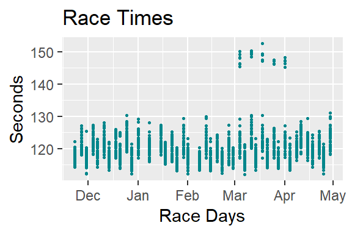

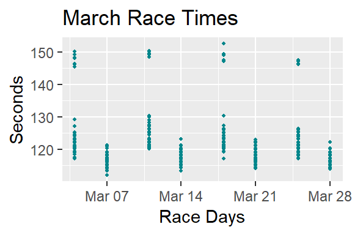

To deal with outliers like these, I would first consider the outliers and also try it without them to see if there is a difference in my model.

Next,is a plot about the frequency of the odds of the racers. The data for this attribute is positively skewed. This will need to be considered depending on the algorithm used for our model. Thankfully, the algorithm Random Forest isn’t sensitive to data skewness, so I should be good to go! The next plot looks at bivariate data (temperature over time). The scatter plot was used to identify easily if there exist a correlation in the data.

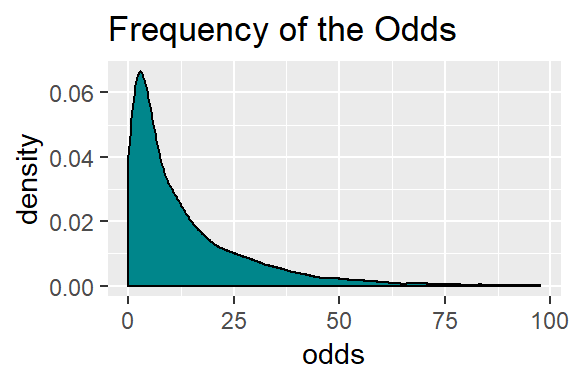

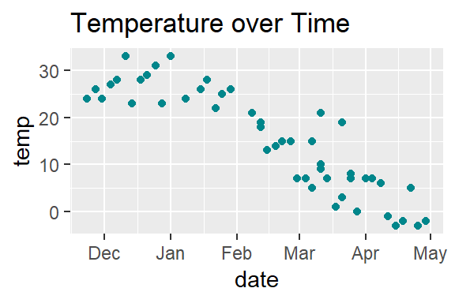

There are few points that are a bit higher than average. Two of them are more noticible during the month of March. I will keep this in mind when I analyze further the data.

Before I merge the dataset, I want to ensure there are no dupplicates.

```r
dupplicate_date <- as.data.frame(table(cond$date)) %>%
                              filter(Freq > 1)
        View(dupplicate_date)
```

```r
# Here I simply decided to remove by indexes. I would of proceeded in a different way if I
        # had more to remove. For example casting them as NA and then dropping them.

        cond <- cond[-21,]
        cond <- cond[-27,]
        cond <- cond[-29,]
        cond <- cond[-29,]
        cond <- cond[-32,]
        cond <- cond[-33,]
        cond <- cond[-42,]
```

```r
# Convert date from factor to date format
        cond$date <- as_date(cond$date)

        # Merge the two datasets together
        full_data <- left_join(res,cond,by="date")

        # View top rows
        full_data %>%
                head
```

```
## # A tibble: 6 x 11
        ##   racenum   pos  hnum  odds date       name  driver trainer seconds  temp
        ##     <int> <int> <int> <dbl> <date>     <fct> <fct>  <fct>     <dbl> <int>
        ## 1       1     1     2 13.0  2015-11-23 Vivi~ Harper Tessa      117.    24
        ## 2       1     2     6  2.6  2015-11-23 Ryder Asher  Quincy     116.    24
        ## 3       1     3     4  6.95 2015-11-23 East~ Chris~ Thomas~    116.    24
        ## 4       1     4     5  0.8  2015-11-23 Simon Kyle   Yahir      115.    24
        ## 5       1     5     1  4.85 2015-11-23 Ashl~ Zane   Carol      117.    24
        ## 6       1     6     3  4    2015-11-23 Carm~ There~ Brian      117.    24
        ## # ... with 1 more variable: cond <fct>
```

Now that I have merged the data sets, I verified if there were any missing values. Turns out that there were! After taking a closer look, I realized that the temperature and condition were missing for February 1st.

```r
is_na_full <- is.na(full_data)
        tbl <- as_tibble(table(is_na_full))
```

Because the conditions are nominal values, I found the mode. As for the weather conditions, I decided to take the average weather for January and February.

```r
Mode <- function(x) {
         ux <- unique(x)
         ux[which.max(tabulate(match(x, ux)))]
        }

        mode <- Mode(full_data$cond)

        # Next is to take a look at the mean for the last month.
        jan_feb_temps <- cond %>%
                          filter(month(date) == 01 | month(date) == 02)

        mean <- mean(jan_feb_temps$temp)
```

- The man for January and February is 20.5714286.
- The most frequent condition is FT.

```r
full_data$temp <- if_else(is.na(full_data$temp),as.integer(20.57),full_data$temp)
        full_data$cond <- if_else(is.na(full_data$cond),"FT",as.character(full_data$cond))
```

### Adding and manipulating the data

Because the question is to find who is the winner, I added a binary “is_winner” column.

```r
full_data <- full_data %>%
                    mutate(is_winner = if_else(full_data$pos == 1,1,0))

        # Convert to Factor
        full_data$is_winner <- full_data$is_winner %>% as.factor()
```

The date column does not provide additional information, so I decided to simply use the month value and drop the date column.

```r
full_data <- full_data %>%
                    mutate(month = month(date)) %>%
                      select(-date)

        # Convert to factor
        full_data$month <- full_data$month %>% as.factor()
```

Because I want to use the Random Forest algorithm, having too many categories in a an attribute makes it very hard to build trees. Therefore, I will analyze the number of categories for the columns “name”, “driver” and “trainer” and use binning to reduce the number of categories. The reason I am doing this, is because I beleive if a horse or driver or trainer performs more races, then this indicates somewhat the level of competitiveness of the horse or individual. By analysing the bar charts, I may determine the size of the bins.

Following are three sets of graphs that represent the distribution of the categories for those columns before and after binning.

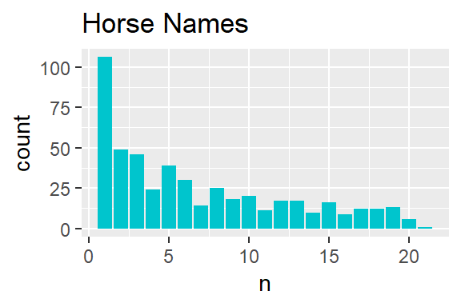

```r
fq_horse_name <- as_tibble(table(full_data$name))

        plot_hname <- ggplot(fq_horse_name) + aes(n) + geom_bar(fill="turquoise3") + ggtitle("Horse Names")
        plot_hname
```

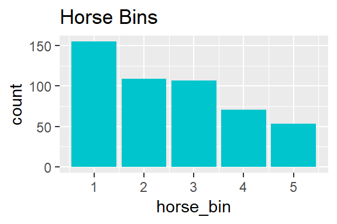

```r
fq_horse_name <- fq_horse_name %>%
                  mutate(horse_bin =  if_else(fq_horse_name$n < 3,1,
                                    if_else(fq_horse_name$n < 6,2,
                                            if_else(fq_horse_name$n < 11,3,
                                                    if_else(fq_horse_name$n <16,4,5
                                                            )))))
        plot_bin_hname <- ggplot(fq_horse_name) + aes(x=horse_bin) + geom_bar(fill="turquoise3") + ggtitle("Horse Bins")
        plot_bin_hname
```

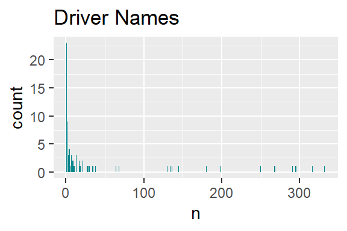

```r
fq_jock_name <- as_tibble(table(full_data$driver))

        plot_jock_name <- ggplot(fq_jock_name) + aes(n) + geom_bar(fill="turquoise4") + ggtitle("Driver Names")
        plot_jock_name
```

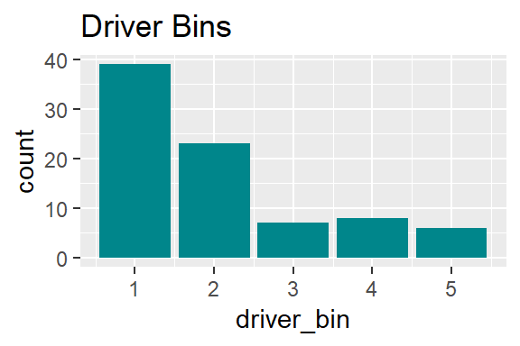

```r
fq_jock_name <- fq_jock_name %>%
          mutate(driver_bin =  if_else(fq_jock_name$n < 5,1,
                                      if_else(fq_jock_name$n < 25,2,
                                              if_else(fq_jock_name$n < 50,3,
                                                      if_else(fq_jock_name$n <200,4,5
                                                      )))))
        plot_jock_bin <- ggplot(fq_jock_name) + aes(driver_bin) + geom_bar(fill="turquoise4") + ggtitle("Driver Bins")
        plot_jock_bin
```

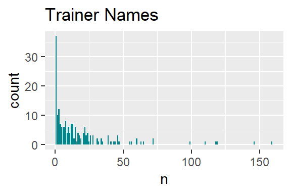

```r
fq_trainer_name <- as_tibble(table(full_data$trainer))

        plot_train_name <- ggplot(fq_trainer_name) + aes(n) + geom_bar(fill="turquoise4") + ggtitle("Trainer Names")
        plot_train_name
```

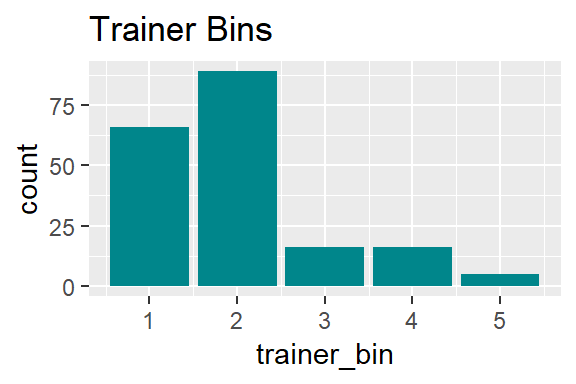

```r
fq_trainer_name <- fq_trainer_name %>%
          mutate(trainer_bin =  if_else(fq_trainer_name$n < 5,1,
                                       if_else(fq_trainer_name$n < 25,2,
                                               if_else(fq_trainer_name$n < 40,3,
                                                       if_else(fq_trainer_name$n <100,4,5
                                                       )))))
        plot_train_bin <- ggplot(fq_trainer_name) + aes(trainer_bin) + geom_bar(fill="turquoise4") + ggtitle("Trainer Bins")
        plot_train_bin
```

Now I will reintegrate the new columns in my dataset and remove the “name”, “driver” and “trainer” columns.

```r
names(fq_horse_name)[names(fq_horse_name) == 'Var1'] <- 'name'
        names(fq_jock_name)[names(fq_jock_name) == 'Var1'] <- 'driver'
        names(fq_trainer_name)[names(fq_trainer_name) == 'Var1'] <- 'trainer'

        full_data <- left_join(full_data,fq_horse_name,by="name")
# remove that n column and horse name
        full_data <- full_data %>%
                        select(-n,-name)

        full_data <- left_join(full_data,fq_jock_name,by="driver")
# remove that n column and horse name
        full_data <- full_data %>%
          select(-n,-driver)

        full_data <- left_join(full_data,fq_trainer_name,by="trainer")
# remove that n column and horse name
        full_data <- full_data %>%
          select(-n,-trainer)
```

Set is_winner column.

```r
full_data <- full_data %>%
          mutate(is_winner = if_else(full_data$pos == 1,1,0))

        # Convert to factor, not character
        full_data$cond <- full_data$cond %>% as.factor()
```

### Data Spliting

```r
train <- full_data[0:2306,]
        testVal <- full_data[2307:3351,] %>% select(is_winner)
        test <- full_data[2307:3351,] %>%
                  select(racenum,odds,hnum,month,temp,cond,horse_bin,driver_bin,trainer_bin)
```

# Prediction

Due to lack of time, I wanted to execute an easy to understand algorithm that works with both numerical and categorical variables.

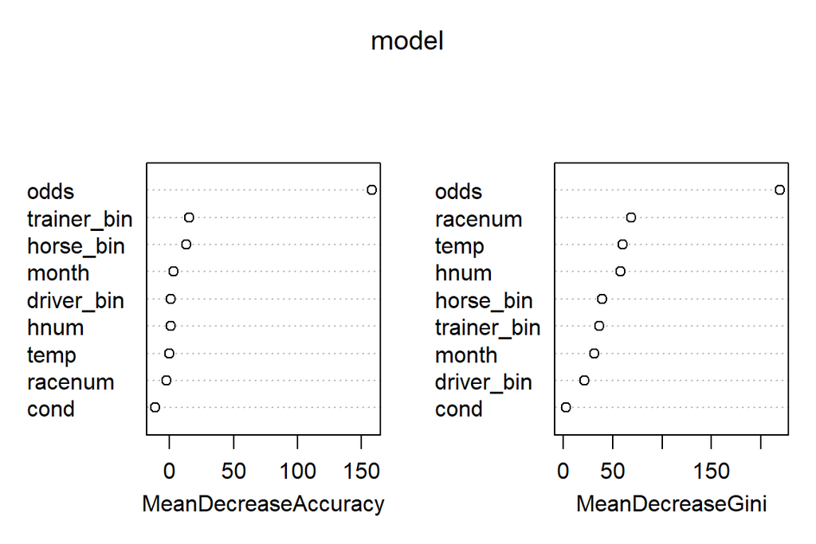

```r
# Train the model
        model <- randomForest(as.factor(is_winner) ~ racenum + hnum +odds + cond +temp + horse_bin +
                              driver_bin + trainer_bin + month,
                            data=train,
                            importance = TRUE,
                            ntree=3000)
        # Plot the importance of the attributes (information gain)
        varImpPlot(model)
```

By looking at these plots, I understand that “cond” does not provide useful information for my model. This makes sense, because most of the cases, the condition is “FT”.

```r
# Train the model
        secondModel <- randomForest(as.factor(is_winner) ~ racenum + hnum +odds + temp + horse_bin +
                              driver_bin + trainer_bin + month,
                            data=train,
                            importance = TRUE,
                            ntree=3000)
```

```r
#remove the cond column from the dataset
        test <- test %>% select(-cond)

        # Start the prediction with the test set
        prediction <- predict(secondModel,test)

        submit <- data.frame(truth = testVal$is_winner, model= prediction)
```

### The results

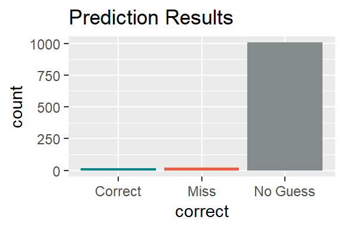

```r
submit <- submit %>%
                    mutate(correct = if_else(submit$model == 1, if_else(submit$truth == 1,"Correct","Miss"),"No Guess"))

        submit$correct <- submit$correct %>% as.factor()

        plot_results <- ggplot(submit) + aes(correct) + geom_bar(fill=c(correct="turquoise4",miss="tomato2","NA"="azure4")) + ggtitle("Prediction Results")
        plot_results
```

I will discuss the results in my conclusion.

# The 9th race

```r
race9 <- read.csv("C:\\Users\\jchar\\OneDrive\\Desktop\\Z\\DS Take Home Assignment3.tar\\Race9.csv")
        race9 <- race9 %>% as.data.frame()

        # Quickly set the name,driver and trainer experience bins
        race9 <- left_join(race9,fq_horse_name,by="name")
# remove that n column and horse name
        race9 <- race9 %>%
                        select(-n,-name)

        race9 <- left_join(race9,fq_jock_name,by="driver")
# remove that n column and horse name
        race9 <- race9 %>%
          select(-n,-driver)

        race9 <- left_join(race9,fq_trainer_name,by="trainer")
# remove that n column and horse name
        race9 <- race9 %>%
          select(-n,-trainer)

        summary(race9)
```

```
##     racenum       hnum            odds                date
        ##  Min.   :9   Min.   :1.000   Min.   : 0.500   2016-04-29:8
        ##  1st Qu.:9   1st Qu.:3.750   1st Qu.: 3.888
        ##  Median :9   Median :5.500   Median :11.600
        ##  Mean   :9   Mean   :5.375   Mean   :16.181
        ##  3rd Qu.:9   3rd Qu.:7.250   3rd Qu.:27.750
        ##  Max.   :9   Max.   :9.000   Max.   :38.200
        ##
        ##    horse_bin       driver_bin     trainer_bin
        ##  Min.   :2.000   Min.   :1.000   Min.   :2.0
        ##  1st Qu.:3.500   1st Qu.:3.750   1st Qu.:3.0
        ##  Median :4.000   Median :5.000   Median :3.5
        ##  Mean   :3.875   Mean   :4.125   Mean   :3.5
        ##  3rd Qu.:5.000   3rd Qu.:5.000   3rd Qu.:4.0
        ##  Max.   :5.000   Max.   :5.000   Max.   :5.0
        ##                                  NA's   :2
```

```r
# Replace NA with 1
        race9$trainer_bin <- if_else(is.na(race9$trainer_bin),1,race9$trainer_bin)

        race9$date <- race9$date %>% as_date()
        cond$date <- cond$date %>% as_date()

        # Merge the two datasets together
        race9 <- left_join(race9,cond,by="date")

        race9 <- race9 %>%
                    mutate(month = month(date)) %>%
                      select(-date)

        # Convert to factor
        race9$month <- race9$month %>% as.factor()

        # View top rows
        race9 %>%
                head
```

```
##   racenum hnum  odds horse_bin driver_bin trainer_bin temp cond month
        ## 1       9    1 34.80         4          5           3   -2   SN     4
        ## 2       9    3 38.20         5          3           4   -2   SN     4
        ## 3       9    4  7.10         4          5           2   -2   SN     4
        ## 4       9    5 25.40         2          4           3   -2   SN     4
        ## 5       9    6  4.10         5          5           5   -2   SN     4
        ## 6       9    7  3.25         5          5           1   -2   SN     4
```

```r
# Remove the cond column
        race9 <- race9 %>% select(-cond)
```

Time to test it with the model.

```r
# Must set the same levels for both data sets to run Random Forest
        levels(race9$month) <- levels(train$month)
        #levels(train$cond) <- levels(race9$cond)
        levels(train$month) <- levels(race9$month)
        #levels(race9$cond) <- levels(train$cond)
```

```r
prediction <- predict(secondModel,race9)

        submit <- data.frame(model= prediction)

        View(submit)
```

My model didn’t predict any winners for the last race.

The use of this algorithm didn’t prove to be very effective in this example. Hence, wasn’t the effort to tweek the parameters to increase the accuracy.

For futher exploration, would be interested in the Support Vector Machine technique to predict the outcome of the race. I would be interested in using SVM because it can handle very sparse data. This means that I would be able to manipulate the data differently, and instead of using bins to classify the experience of the name of the horse, the driver and the trainer, I could use binary attributes, known as bitMaps. I beleive this would be a better approach for this kind of problem. In the case of a ensemble method with decision trees as the base classifier, it doesn’t handle sparse data well, known as the curse of dimentionality.

Thanks for reading!